# Behavioral Data Science Project - Group 6

Avisek Choudhury Ben Corriveau Cindy Nikolai

11/06/2020

# Introduction

Airport executives and state and local officials are curious about customer satisfaction at San Francisco International Airport. Business and tourist travelers are a huge source of revenue for the city. SFO is in a prime location relative to other west-coast cities, and it is well situated as a long-term layout spot for international travel to Asia. Because of this, identifying current strengths of the airport and areas for improvement are critical to increasing traffic and revenue.

Marketing executives developed a survey and administered it to customers over the previous year. SFO invested a lot of time and resources in collected comprehensive data for 3,234 customers on 100 variables. They have now hired us as their data science consultants to gain insights into these data. The SFO team is not well-versed in data science methodology, but they have a few key areas of interest for us to look into.

## Part A

### Hypothesis/Hypotheses

#### Question 1

Customers were asked to rate their opinion of the “SFO Airport as a whole” on a scale from 1 (“unacceptable”) to 5 (“outstanding”). The executives want to know if there are patterns across the satisfied or dissatisfied customers based on demographic characteristics, such as sex, age group, and income level.

We are theorizing that there will be distinct patterns that emerge in the deomgraphic data, but are yet unsure of what they will show.

#### Question 2

The executives also want to know if customer satisfaction can be broken down into different attributes of the airport. Knowing this will help the team target specific strengths or areas of improvement. The central feature the customer satisfaction survey is a 14-question portion of the survey asking customers to rate satisfaction with different aspects of the airport (see Question 6 in the data directory). The executives want us to perform a quantitative analysis to determine if there are broad themes that emerge from this part of the survey.

Based on the fact that the questions fall into distinct categories, we are theorzing that there are distinct underlying factors that influence overall satisfaction. What we do not know though is which are the most/least important areas of the airport as it pertains to overall satisfaction.

#### Question 3

Free-response comments, either good or bad, were collected in addition to the 14-item quantitative survey. The executives are not quite sure how to examine it without going through individual surveys one by one, but they want you to see if there are any concepts or insights that arise from these responses. Do the free responses relate to the findings in a) or b) at all?

We strongly believe that the free response questions will align with the overall satisfaction scores.

### Data Description/EDA

As mentioned above, our data set had 3,234 responses on 100 variables Of those 100 variables, we were only really interested in the Question 6 responses, and comments (15 columns). Plus, we are including the demographic information: Age Group, Gender, and Income. To ensure we had a good sample size, we reviewed missingness for each column. We were pleased to see that all of the Question 6 responses had fewer than 7% missing data.

### Analysis plan

#### Question 1

For the first question, we plan to start by visualizing the relationship between overall satisfactin and the various demographic groups. We should be able to develop initial observations that we can test further with a regression model. The regression model should be able to definitively prove/disprove our initial theories based on the visuals.

#### Question 2

For the second question, we feel that the best approach will be factor analysis. This should allow us to see if there are commonalities in the reponses, and from there determine which questions appear to be the “most important,” or at least most indicative of positive overall satisfaction.

#### Question 3

For the third question, we believe that sentiment analysis will be the best way to gather insight from free-form responses. We should easily be able to determine if the overall sentiment matches the overall numerical responses.

### Results

#### Question 1

Based on our demographic analysis, we see that only 4 of the demographic categories have a statistically significant impact on the overall rating: `GenderMale`, `Income$50,000-$100,00`, `Income$100,001-$150,000`, and `IncomeOver $150,000`. Each of these 4 categories appears to have an overall negative influence on the satisfaction score. What this tells us that, in general, Men tend to have more negative opinions of the airport. Also, the overall opinion of SFO seems to decline as a person’s income increases.

#### Question 2

Overall, we have found that though there seem to be four total “themes”, there are only two “themes” that have a noticeable relationship to overall satisfaction: 1 - Food services and shopping 2 - Navigational signs and moving walkways

Of those, it would seem that the navigational signs and moving walkways have a higher correlation with overall satisfaction. From this, we conclude that people are often in a hurry and prioritize the ability to get to their get quickly and easily. Also somewhat important are the availble food services and shops.

#### Question 3

### Discussion

# Part B

### Research Question and Hypothesis

#### EDA

#### Analysis Plan

#### Results

#### Discussion

# Appendix

#### Load Data and Libraries

```r
#Import the libraries
library(tidyverse)
library(haven)
library(plotly)
library(reshape2)
library(lmtest)
library(lme4)
library(psych)
library(GPArotation)
library(ggcorrplot)
library(tidytext)
library(wordcloud2)
library(sentimentr)
library(lexicon)
library(magrittr)
library(tidyr)
library(stm)

#Read the data set
sfoDf <- read_delim('/Users/benjamincorriveau/OneDrive/School/BehavioralDS/SFO_survey_withText.txt', delim="\t")
```

#### EDA

Let’s get the percent of empyty rows for each column to get an idea of missingness.

```r
sapply(sfoDf, function(x) round(sum(is.na(x))/length(x),3))
```

```
##     RESPNUM       CCGID        TERM      STRATA       ATYPE     AIRLINE
##       0.000       0.000       0.000       0.000       0.000       0.000
##        DEST     GATENUM     INTDATE          Q1        Q2_1        Q2_2
##       0.000       0.000       0.000       0.003       0.000       0.021
##        Q2_3        Q2_4        Q2_5        Q2_6        Q3_1        Q3_2
##       0.971       0.998       1.000       1.000       0.000       0.001
##        Q3_3        Q3_4        Q3_5        Q3_6         Q3A         Q4A
##       0.997       1.000       1.000       1.000       0.007       0.040
##         Q4B         Q4C          Q5       Q5AVG         SAQ         Q6A
##       0.086       0.069       0.008       0.008       0.000       0.032
##         Q6B         Q6C         Q6D         Q6E         Q6F         Q6G
##       0.025       0.033       0.024       0.023       0.024       0.035
##         Q6H         Q6I         Q6J         Q6K         Q6L         Q6M
##       0.036       0.045       0.056       0.059       0.066       0.067
##         Q6N      Q7COM1      Q7COM2      Q7COM3        Q7A1        Q7A2
##       0.035       0.530       0.827       0.945       0.978       0.988
##        Q7A3         Q8A         Q8B         Q8C         Q8D         Q8E
##       0.995       0.015       0.045       0.046       0.055       0.036
##         Q8F      Q8COM1      Q8COM2      Q8COM3          Q9     Q9APOS1
##       0.021       0.970       0.998       1.000       0.015       0.703
##     Q9APOS2     Q9APOS3     Q9ANEG1     Q9ANEG2     Q9ANEG3     Q9ANTR1
##       0.958       0.997       0.994       1.000       1.000       0.954
##     Q9ANTR2     Q9ANTR3         Q10         Q11       Q11A1       Q11A2
##       0.996       1.000       0.033       0.860       0.929       0.979
##       Q11A3         Q12        Q13A        Q13B     Q13_COM     Q13COM1
##       0.997       0.000       0.029       0.065       1.000       0.892
##     Q13COM2     Q13COM3         Q14        Q14A       Q14A1       Q14A2
##       0.994       1.000       0.032       1.000       0.903       0.988
##       Q14A3         Q15      SFFLAG     COUNTRY         Q17         AGE
##       0.998       0.027       0.000       0.055       0.029       0.029
##         Q18         Q19         INC        MAIL        LANG    DESTMARK
##       0.058       0.201       0.201       0.000       0.000       0.000
## DESTINATION     DESTGEO      WEIGHT  Location.1 Q7_text_All
##       0.000       0.000       0.000       1.000       0.519
```

We see lot of columns with huge no of missing values. Let’s check the columns with more than 50% values are missing.

```r
#Count the NA or missing Rows for each columns
unlist(sapply(sfoDf, function(x) {
  if (sum(is.na(x)) > length(x)* 0.5)
    return (sum(is.na(x)))
  }))
```

```
##        Q2_3        Q2_4        Q2_5        Q2_6        Q3_3        Q3_4
##        3140        3226        3234        3234        3225        3234
##        Q3_5        Q3_6      Q7COM1      Q7COM2      Q7COM3        Q7A1
##        3234        3234        1715        2675        3056        3164
##        Q7A2        Q7A3      Q8COM1      Q8COM2      Q8COM3     Q9APOS1
##        3194        3219        3137        3229        3234        2275
##     Q9APOS2     Q9APOS3     Q9ANEG1     Q9ANEG2     Q9ANEG3     Q9ANTR1
##        3098        3223        3215        3234        3234        3084
##     Q9ANTR2     Q9ANTR3         Q11       Q11A1       Q11A2       Q11A3
##        3220        3234        2782        3005        3165        3223
##     Q13_COM     Q13COM1     Q13COM2     Q13COM3        Q14A       Q14A1
##        3234        2886        3214        3234        3234        2919
##       Q14A2       Q14A3  Location.1 Q7_text_All
##        3194        3229        3234        1677
```

#### Research Question 1

The first step is to convert the columns for age, income and sex into something easier to read.

```r
#Convert the Sex
sfoDf['Gender'] <- ifelse(sfoDf$Q18 == 1, "Male",
                          ifelse(sfoDf$Q18 == 2, "Female", "Blank"))
#Convert the Age Group column
sfoDf['Age_Group'] <- ifelse(sfoDf$Q17 == 1, "Under 18",
       ifelse(sfoDf$Q17 == 2, "18-24",
              ifelse(sfoDf$Q17 == 3, "25-34",
                     ifelse(sfoDf$Q17 == 4, "35-44",
                            ifelse(sfoDf$Q17 == 5, "45-54",
                                   ifelse(sfoDf$Q17 == 6, "55-64",
                                          ifelse(sfoDf$Q17 == 7, "65 and Over",
                                                ifelse(sfoDf$Q17 == 8, "Don't Know/Refused",
                                                       ifelse(sfoDf$Q17 == 0, "Blank", "NA")))))))))

#Convert the Income Column
sfoDf['Income'] <- ifelse(sfoDf$Q19 == 1, "Under $50,000",
                          ifelse(sfoDf$Q19 == 2, "$50,000-$100,00",
                                 ifelse(sfoDf$Q19 == 3, "$100,001-$150,000",
                                        ifelse(sfoDf$Q19 == 4, "Over $150,000",
                                               ifelse(sfoDf$Q19 == 5, "Other", "Blank")))))
```

Let’s take a look at satisfaction ratings (Question 6n) grouped by various attributes (gender, income, age, etc.)

```r
satisfaction_data <- sfoDf %>%
  select('Gender','Age_Group','Income','Q6N') %>%
  melt(., id.vars=c('Age_Group','Gender','Income'), value.name = 'Score') %>%
  select(-'variable') %>%
  na.omit(.)

satisfaction_data$Income <- factor(satisfaction_data$Income,levels = c('Under $50,000',"$50,000-$100,00","$100,001-$150,000","Over $150,000","Other","Blank"))

satisfaction_data$Age_Group <- factor(satisfaction_data$Age_Group, levels = c( "Under 18","18-24","25-34","35-44","45-54","55-64","65 and Over","Don't Know/Refused","Blank", "NA"))
```

We will start by looking at responses grouped by Gender and Income

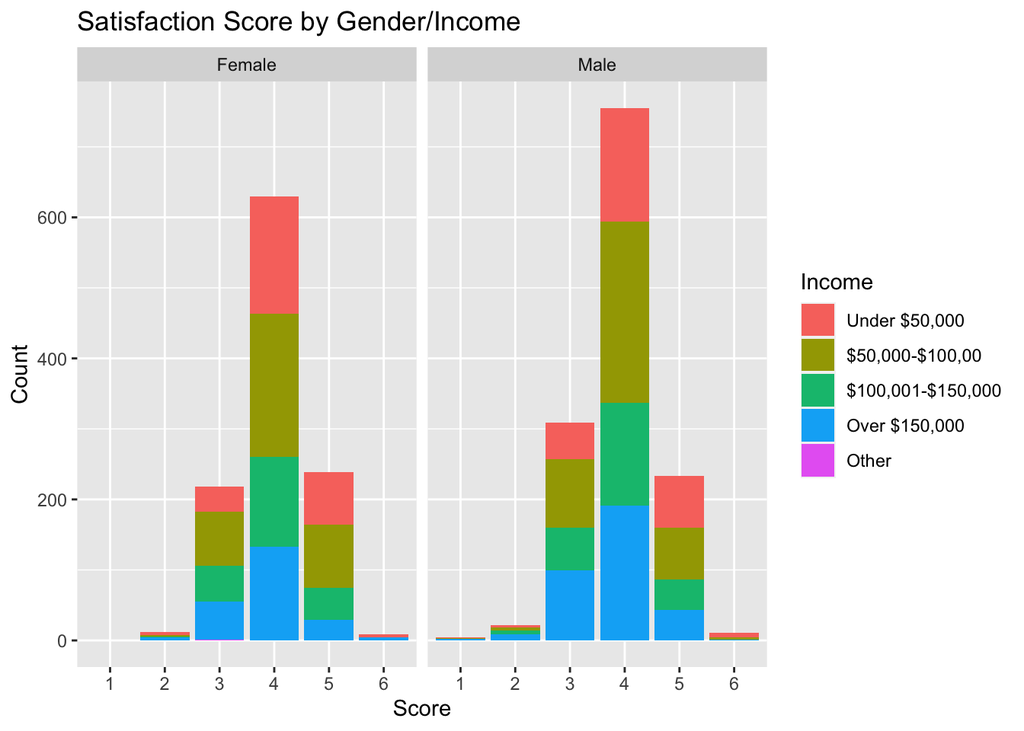

```r
ggplot(satisfaction_data, aes(x=as.factor(Score), fill=Income)) +
  geom_bar(stat='count') +
  facet_wrap(~Gender) +
  labs(title="Satisfaction Score by Gender/Income", x='Score', y='Count')
```

We can see that the most common response for “How does SFO Airport rate as a whole” was a 4, which is one step below the highest score. Worth noting here is that while 6 is an option, it represents “Have never used or visited/not applicable” so we consider a 5 the highest score. The largest number of respondents who gave SFO a 4 appear to have income within `$50,000 - $100,000`. This could be because they liked it best, or because they are the largest respondent group. We also see that male respondents had a higher proportion of ‘3’ responses than ‘5’, the opposite being true for females. We will want to test this theory later in a regression model.

Now let’s take a look at the responses grouped by Income and Age

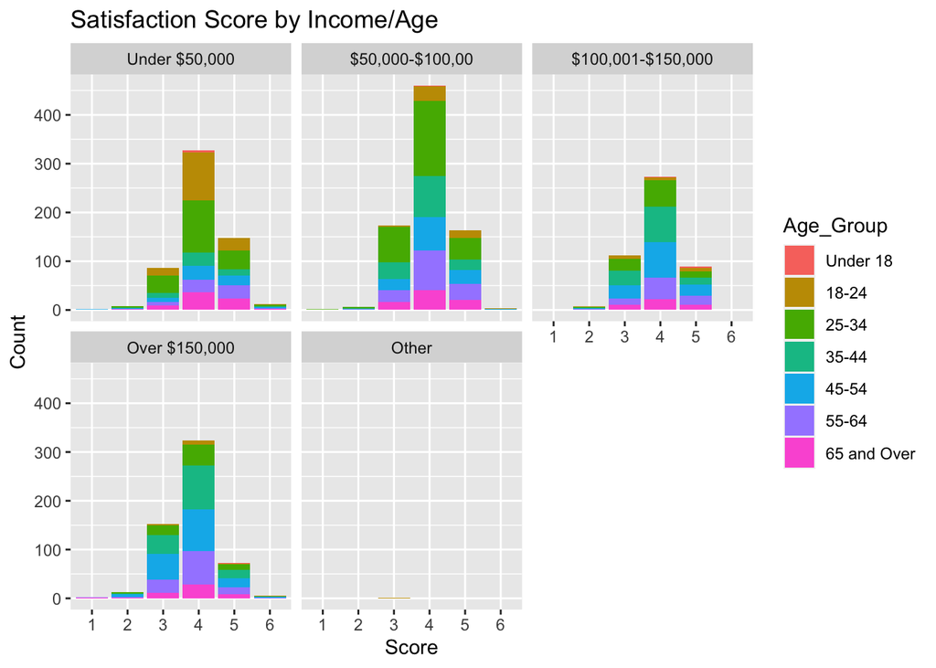

```r
ggplot(satisfaction_data, aes(x=as.factor(Score), fill=Age_Group)) +
  geom_bar(stat='count') +
  facet_wrap(~Income) +
  labs(title="Satisfaction Score by Income/Age", x='Score', y='Count')
```

Though we have a general idea of the distribution, we want to run a regression model to see if we see any kind of pattern.

```r
lm_score <- lm(Score ~ Gender + Age_Group + Income,data = satisfaction_data)
summary(lm_score)
```

```
##
## Call:
## lm(formula = Score ~ Gender + Age_Group + Income, data = satisfaction_data)
##
## Residuals:
##     Min      1Q  Median      3Q     Max
## -3.0818 -0.2010  0.0401  0.2066  2.2599
##
## Coefficients:
##                         Estimate Std. Error t value Pr(>|t|)
## (Intercept)              4.44719    0.22431  19.826  < 2e-16 ***
## GenderMale              -0.07264    0.02886  -2.517   0.0119 *
## Age_Group18-24          -0.24620    0.22768  -1.081   0.2796
## Age_Group25-34          -0.38981    0.22469  -1.735   0.0829 .
## Age_Group35-44          -0.34613    0.22553  -1.535   0.1250
## Age_Group45-54          -0.29279    0.22550  -1.298   0.1943
## Age_Group55-64          -0.21121    0.22594  -0.935   0.3500
## Age_Group65 and Over    -0.22295    0.22742  -0.980   0.3270
## Income$50,000-$100,00   -0.12186    0.03957  -3.079   0.0021 **
## Income$100,001-$150,000 -0.18440    0.04538  -4.063 5.00e-05 ***
## IncomeOver $150,000     -0.28834    0.04443  -6.490 1.04e-10 ***
## IncomeOther             -1.20098    0.70572  -1.702   0.0889 .
## ---
## Signif. codes:  0 '***' 0.001 '**' 0.01 '*' 0.05 '.' 0.1 ' ' 1
##
## Residual standard error: 0.704 on 2430 degrees of freedom
## Multiple R-squared:  0.03452,    Adjusted R-squared:  0.03015
## F-statistic: 7.899 on 11 and 2430 DF,  p-value: 1.249e-13
```

Based on this simple regression, we see that only 4 of the demographic categories have a statistically significant impact on the overall rating: `GenderMale`, `Income$50,000-$100,00`, `Income$100,001-$150,000`, and `IncomeOver $150,000`. Each of these 4 categories appears to have an overall negative influence on the satisfaction score.

#### Research Question 2

To answer this question, we will conduct a factor analysis to see if patterns emerge. We will need to look at the responses to all parts of Question 6:

How does SFO rate on each of the following attributes? 6a. Artwork and exhibitions 6b. Restaurants 6c. Retail shops and concessions 6d. Signs and directions inside SFO 6e. Escalators/elevators/moving walkways 6f. Information on screens/monitors 6g. Information booths (lower level near baggage claim) 6h. Information booths (upper level – departure area) 6i. Signs and directions on SFO airport roadways 6j. Airport parking facilities 6k. AirTrain 6l. Long term parking lot shuttle 6m. Airport rental car center 6n. SFO Airport as a whole

```r
short_survey <- sfoDf %>%
  select(Q6A:Q6N)
```

Let’s take a look at a correlation plot to see if any patterns jump out.

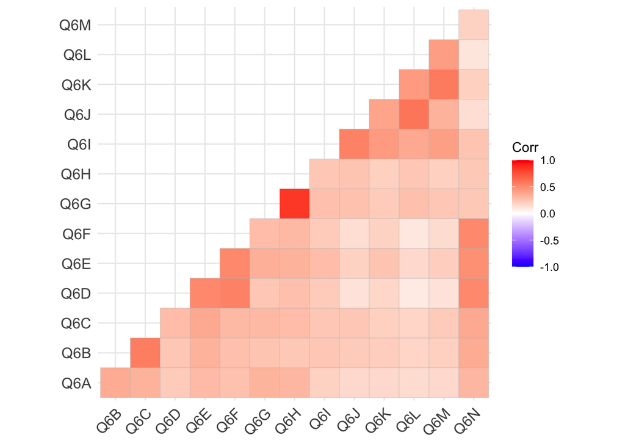

```r
short_survey %>%
  cor(., use="complete.obs") %>%
  ggcorrplot(type = "lower")
```

Immediately we see that questions about the information booths (6H and 6G) are almost perfectly positively correlated, likely meaning the information booth quality is the same, regardless of its location. We also see there is a string positive correlation among many of the travel and parking related responses (6J, 6K, 6L, 6M).

What we see in the correlation plot leads us to think there may be some themes here, so we will do a more thorough factor analysis to see if this holds true. To begin, we will see how many factors will be best to use.

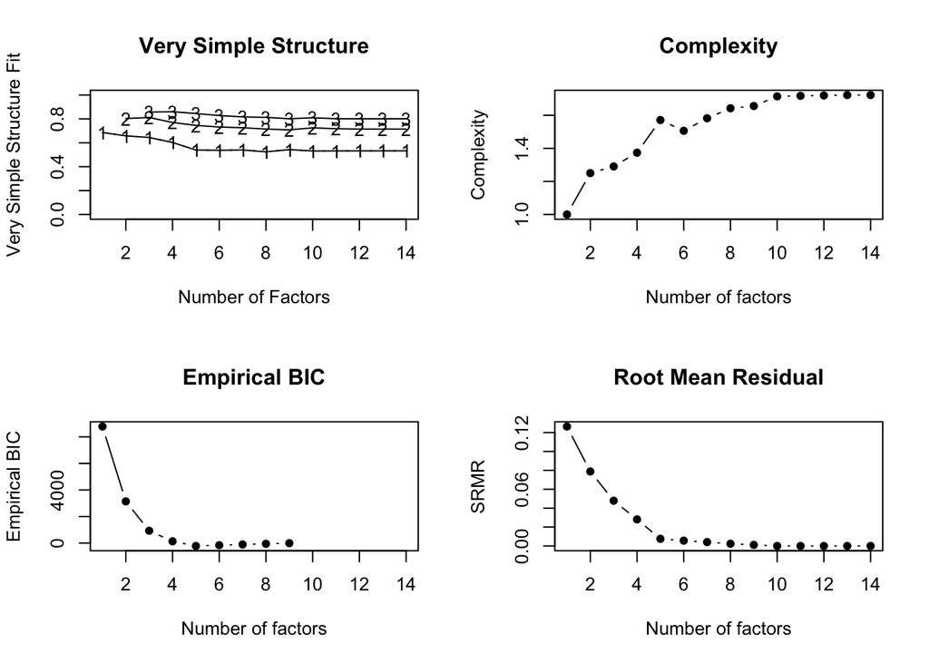

```
##
## Number of factors
## Call: vss(x = x, n = n, rotate = rotate, diagonal = diagonal, fm = fm,
##     n.obs = n.obs, plot = FALSE, title = title, use = use, cor = cor)
## VSS complexity 1 achieves a maximimum of 0.69  with  1  factors
## VSS complexity 2 achieves a maximimum of 0.81  with  3  factors
## The Velicer MAP achieves a minimum of 0.03  with  3  factors
## Empirical BIC achieves a minimum of  -216.77  with  5  factors
## Sample Size adjusted BIC achieves a minimum of  -62.91  with  5  factors
##
## Statistics by number of factors
##    vss1 vss2   map dof   chisq     prob sqresid  fit RMSEA    BIC  SABIC
## 1  0.69 0.00 0.043  77 8.2e+03  0.0e+00    10.0 0.69 0.180 7550.7 7795.4
## 2  0.66 0.80 0.033  64 5.0e+03  0.0e+00     6.3 0.80 0.155 4523.2 4726.5
## 3  0.64 0.81 0.033  52 1.7e+03 4.9e-324     4.6 0.86 0.099 1289.9 1455.1
## 4  0.60 0.77 0.037  41 8.3e+02 2.3e-147     3.5 0.89 0.077  497.4  627.7
## 5  0.54 0.75 0.045  31 8.9e+01  1.6e-07     2.9 0.91 0.024 -161.4  -62.9
## 6  0.54 0.73 0.065  22 5.2e+01  3.0e-04     2.5 0.92 0.021 -125.6  -55.7
## 7  0.54 0.73 0.091  14 3.6e+01  9.1e-04     2.3 0.93 0.022  -76.7  -32.3
## 8  0.52 0.72 0.114   7 1.7e+01  2.1e-02     2.1 0.93 0.020  -40.1  -17.8
## 9  0.54 0.71 0.153   1 2.6e+00  1.1e-01     2.1 0.93 0.022   -5.5   -2.3
## 10 0.53 0.73 0.212  -4 6.7e-05       NA     2.2 0.93    NA     NA     NA
## 11 0.53 0.72 0.365  -8 1.2e-05       NA     2.2 0.93    NA     NA     NA
## 12 0.53 0.71 0.635 -11 7.1e-07       NA     2.2 0.93    NA     NA     NA
## 13 0.53 0.71 1.000 -13 1.0e-10       NA     2.2 0.93    NA     NA     NA
## 14 0.53 0.71    NA -14 1.0e-10       NA     2.2 0.93    NA     NA     NA
##    complex  eChisq    SRMR  eCRMS   eBIC
## 1      1.0 9.4e+03 1.3e-01 0.1374 8778.4
## 2      1.3 3.7e+03 7.9e-02 0.0940 3138.4
## 3      1.3 1.3e+03 4.8e-02 0.0633  928.9
## 4      1.4 4.7e+02 2.8e-02 0.0419  133.7
## 5      1.6 3.4e+01 7.6e-03 0.0130 -216.8
## 6      1.5 1.9e+01 5.6e-03 0.0115 -159.1
## 7      1.6 9.8e+00 4.1e-03 0.0104 -103.3
## 8      1.6 3.3e+00 2.4e-03 0.0085  -53.3
## 9      1.7 7.4e-01 1.1e-03 0.0107   -7.3
## 10     1.7 2.4e-05 6.3e-06     NA     NA
## 11     1.7 2.5e-06 2.1e-06     NA     NA
## 12     1.7 1.3e-07 4.8e-07     NA     NA
## 13     1.7 2.8e-11 6.9e-09     NA     NA
## 14     1.7 2.8e-11 6.9e-09     NA     NA
```

```r
short_survey %>%
  nfactors()
```

From the data above, we see that either 3 or 4 factors will likely be best. We will try both to see if there is a meaningful difference.

```r
surveyFA_3 <- short_survey %>%
  fa(., nfactors = 3, rotate = "promax")

surveyFA_3$loadings
```

```
##
## Loadings:
##     MR1    MR2    MR3
## Q6A  0.336         0.163
## Q6B  0.468  0.130
## Q6C  0.477  0.116
## Q6D  0.744 -0.114
## Q6E  0.692
## Q6F  0.733
## Q6G                0.997
## Q6H                0.882
## Q6I  0.116  0.615
## Q6J         0.719
## Q6K         0.692
## Q6L -0.148  0.709
## Q6M         0.647
## Q6N  0.797        -0.120
##
##                  MR1   MR2   MR3
## SS loadings    2.808 2.354 1.833
## Proportion Var 0.201 0.168 0.131
## Cumulative Var 0.201 0.369 0.500
```

With 3 factors, we see that people who answered positively about shopping, navigational aides, and moving walkways (6A,6B,6C,6D,6E,6F) also tended to answer positively for the overall score (6N). One interpretation of factor MR1 as people are often in a hurry to catch their flight and appreciate being able to move through the airport quickly. Another option is that people are appreciative of the food and shopping.

We also see in factor MR2 the same parking and transportation correlation we saw in the plot. People who answered positively about the parking also did so about airport transportation services (6I,6J,6K,6L,6M). However, positive responses in these questions did not appear to effect the overall score.

Finally, we see that factor MR3 is the grouping of information booths we saw in the correlation plot. Positive responses about either floor’s information booth tended match positive responses for the other. However, positive responses in these questions did not appear to effect the overall score.

Next we will review 4 factors to see if any further patterns emerge.

```r
surveyFA_4 <- short_survey %>%
  fa(., nfactors = 4, rotate = "promax")

surveyFA_4$loadings
```

```
##
## Loadings:
##     MR2    MR1    MR3    MR4
## Q6A                0.139  0.385
## Q6B                       0.872
## Q6C                       0.700
## Q6D         0.815        -0.107
## Q6E         0.623
## Q6F         0.757
## Q6G                0.944
## Q6H                0.914
## Q6I  0.620  0.114
## Q6J  0.692
## Q6K  0.702
## Q6L  0.693 -0.121
## Q6M  0.646
## Q6N         0.643         0.160
##
##                  MR2   MR1   MR3   MR4
## SS loadings    2.259 2.094 1.780 1.450
## Proportion Var 0.161 0.150 0.127 0.104
## Cumulative Var 0.161 0.311 0.438 0.542
```

We see mostly the same results here, but now the shopping, food, and navigational information responses are in different factors, with navigation and moving walkways (MR1) having a larger positive correlation with a positive overall score. Food and shopping (MR4) also seems to be related to a positive overall score, but to a lesser extent.

We see the same results for both factors MR2 (transportation and parking) and MR3 (information booths).

With 4 factors, it becomes a bit more clear what most respondents seem to favor: clear navigational aides and moving walkways (MR1). While shopping is also important, the priority for travelers seems to be ease/speed of navigating within the airport.

#### Research Question #3

For sentiment analysis let’s have a look at the combined comment column in the given dataset.

```r
#Comment Column
sfoDf$Q7_text_All %>%
  na.omit %>%
  head(10)
```

```
##  [1] " Airport Layout-Terminals too far away/confusing/too difficult/takes too long to get around airport/no way to get between terminals after getting through security/domestic airlines in international terminal  Smoking areas-more needed/inconveniently located  Add traffic delays/other informat…
##  [2] " Food too expensive  Positive comment about wifi  Security/Customs lines/procedures long/inefficient/ineffective"
##  [3] " Signage outside airport confusing/hard to get to airport/difficult to find correct terminal"
##  [4] " Security/Customs lines/procedures long/inefficient/ineffective  Signage inside airport confusing/small/hard to find gate or airline"
##  [5] " Security/Customs lines/procedures long/inefficient/ineffective"
##  [6] " General cleanliness neg comment  Need more artwork/exhibitions/change artwork more frequently"
##  [7] " Wifi-not free long enough/difficult to access/doesn’t cover entire airport/overloaded/didn’t know was available"
##  [8] " Signage inside airport confusing/small/hard to find gate or airline"
##  [9] " Signage inside airport confusing/small/hard to find gate or airline  Signage outside airport confusing/hard to get to airport/difficult to find correct terminal  Need Starbucks/Peets/coffee house type restaurants (both before and after security)   Security/Customs lines/procedures long/ine…
## [10] " Security/Customs lines/procedures long/inefficient/ineffective"
```

Let’s remove the forward slash and hyphens from the comments and replace that with blank space.

```r
#Remove the Slash
sfoDf$Q7_text_All <- gsub(pattern = "/",
                          replacement = " ",
                          sfoDf$Q7_text_All)
#Remove the hyphens
sfoDf$Q7_text_All <- gsub(pattern = "-",
                          replacement = " ",
                          sfoDf$Q7_text_All)
#Verify the data
sfoDf$Q7_text_All %>%
  na.omit %>%
  head(10)
```

```
##  [1] " Airport Layout Terminals too far away confusing too difficult takes too long to get around airport no way to get between terminals after getting through security domestic airlines in international terminal  Smoking areas more needed inconveniently located  Add traffic delays other informat…
##  [2] " Food too expensive  Positive comment about wifi  Security Customs lines procedures long inefficient ineffective"
##  [3] " Signage outside airport confusing hard to get to airport difficult to find correct terminal"
##  [4] " Security Customs lines procedures long inefficient ineffective  Signage inside airport confusing small hard to find gate or airline"
##  [5] " Security Customs lines procedures long inefficient ineffective"
##  [6] " General cleanliness neg comment  Need more artwork exhibitions change artwork more frequently"
##  [7] " Wifi not free long enough difficult to access doesn’t cover entire airport overloaded didn’t know was available"
##  [8] " Signage inside airport confusing small hard to find gate or airline"
##  [9] " Signage inside airport confusing small hard to find gate or airline  Signage outside airport confusing hard to get to airport difficult to find correct terminal  Need Starbucks Peets coffee house type restaurants (both before and after security)   Security Customs lines procedures long ine…
## [10] " Security Customs lines procedures long inefficient ineffective"
```

Let’s check the count of distinct words used by each age group. We can remove the stop words before do the count.

```r
#Word Count by each Inmate
wordDf <- sfoDf %>%
  select(Q7_text_All, Q17, Age_Group) %>%
   rename(Age = Q17,
         Comments = Q7_text_All) %>%
  unnest_tokens(word, Comments) %>%
  anti_join(stop_words) %>%
  na.omit() %>%
  group_by(Age_Group, Age, word) %>%
  summarise(count = n())
#Check the data set
head(wordDf, n = 20)
```

```
## # A tibble: 20 x 4
## # Groups:   Age_Group, Age [1]
##    Age_Group   Age word          count
##    <chr>     <dbl> <chr>         <int>
##  1 18-24         2 ac                2
##  2 18-24         2 access            5
##  3 18-24         2 air               3
##  4 18-24         2 airline          11
##  5 18-24         2 airlines          4
##  6 18-24         2 airport          43
##  7 18-24         2 airtrain          4
##  8 18-24         2 amenities         9
##  9 18-24         2 announcements     1
## 10 18-24         2 artwork           6
## 11 18-24         2 atm’s             3
## 12 18-24         2 bad               3
## 13 18-24         2 bart              3
## 14 18-24         2 bilingual         1
## 15 18-24         2 booth             1
## 16 18-24         2 bring             1
## 17 18-24         2 business          5
## 18 18-24         2 carts             1
## 19 18-24         2 chain             8
## 20 18-24         2 change            9
```

Let’s count positive and negative words for each age group and calculate the sentiment.

```r
#Count positive and negative words
wordSent_bing <- wordDf %>%
  inner_join(get_sentiments("bing")) %>%
  group_by(Age_Group, Age, sentiment) %>%
  count(sentiment)  %>%
  spread(sentiment, n, fill = 0) %>%
  mutate(sentiment = positive - negative)
#Print the dataset
head(wordSent_bing, n= 10)
```

```
## # A tibble: 8 x 5
## # Groups:   Age_Group, Age [8]
##   Age_Group            Age negative positive sentiment
##   <chr>              <dbl>    <dbl>    <dbl>     <dbl>
## 1 18-24                  2       16       10        -6
## 2 25-34                  3       17       11        -6
## 3 35-44                  4       18       11        -7
## 4 45-54                  5       19       12        -7
## 5 55-64                  6       18       11        -7
## 6 65 and Over            7       18       11        -7
## 7 Don't Know/Refused     8        3        1        -2
## 8 Under 18               1        1        1         0
```

Let’s plot the positive and negative sentient count for each age group .

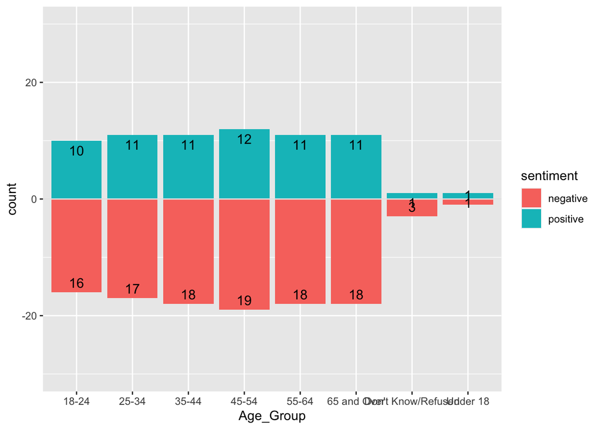

```r
#Generate the Dataset for the Plot
plotDf <- wordDf %>%
  inner_join(get_sentiments("bing")) %>%
  group_by(Age_Group, Age, sentiment) %>%
  count(sentiment) %>%
  rename(count = n)
#Generate the Barplot for the Positive/Negative Sentiment
#For Each Age Group
ggplot(plotDf, aes(Age_Group), ylim(-30:30)) +
geom_bar(data = subset(plotDf, sentiment == "positive"),
   aes(y = count, fill = sentiment), stat = "identity", position = "dodge") +
geom_bar(data = subset(plotDf, sentiment == "negative"),
   aes(y = -count, fill = sentiment), stat = "identity", position = "dodge") +
geom_hline(yintercept = 0,colour = "grey90") +
  #Now Add the Tect to it
geom_text(data = subset(plotDf, sentiment == "positive"),
      aes(Age_Group, count, group=sentiment, label=count),
        position = position_dodge(width=0.9), vjust = 1.5, size=4) +
geom_text(data = subset(plotDf, sentiment == "negative"),
      aes(Age_Group, -count, group=sentiment, label=count),
        position = position_dodge(width=0.9), vjust = -.5, size=4) +
    coord_cartesian(ylim = c(-30, 30))
```

Now instead of `bing` we can use `affin` which assigns a value positive/negative to each word and calculate the average sentiment for age group we have.

```r
#Calculate Average sentiment for each inmate
avgSentAgeGrp <- wordDf %>%
  inner_join(get_sentiments("afinn")) %>%
  group_by(Age_Group) %>%
  summarise( totalWords = sum(count), sentSum = sum(value)) %>%
  mutate(Avg_Sentiment = sentSum / totalWords)
#Print the dataset
head(avgSentAgeGrp, n=20)
```

```
## # A tibble: 8 x 4
##   Age_Group          totalWords sentSum Avg_Sentiment
##   <chr>                   <int>   <dbl>         <dbl>
## 1 18-24                     105      -8       -0.0762
## 2 25-34                     402      -7       -0.0174
## 3 35-44                     337     -11       -0.0326
## 4 45-54                     366     -12       -0.0328
## 5 55-64                     358     -11       -0.0307
## 6 65 and Over               236      -8       -0.0339
## 7 Don't Know/Refused          3      -4       -1.33
## 8 Under 18                    8       2        0.25
```

Here also we see the average sentiment is negative almost all age range except the population under 18.

Now let’s analyze the sentiments by gender.

```r
#Word Count by each Inmate
wordDf <- sfoDf %>%
  select(Gender,  Q7_text_All) %>%
   rename(Comments = Q7_text_All) %>%
  unnest_tokens(word, Comments) %>%
  anti_join(stop_words) %>%
  na.omit() %>%
  group_by(Gender, word) %>%
  summarise(count = n())
#Check the data set
head(wordDf, n = 20)
```

```
## # A tibble: 20 x 3
## # Groups:   Gender [1]
##    Gender word          count
##    <chr>  <chr>         <int>
##  1 Female ac                5
##  2 Female access           25
##  3 Female air              13
##  4 Female airline          98
##  5 Female airlines         64
##  6 Female airport         323
##  7 Female airtrain         19
##  8 Female allowed           3
##  9 Female amenities        64
## 10 Female announcements    15
## 11 Female artwork          50
## 12 Female atm’s            19
## 13 Female automated         1
## 14 Female bad              13
## 15 Female baggage           3
## 16 Female bart             25
## 17 Female bilingual        15
## 18 Female booth            26
## 19 Female bring             4
## 20 Female business         22
```

Let’s count positive and negative words for each sex and calculate the sentiment.

```r
#Count positive and negative words
wordSent_bing <- wordDf %>%
  inner_join(get_sentiments("bing")) %>%
  group_by(Gender, sentiment) %>%
  count(sentiment)  %>%
  spread(sentiment, n, fill = 0) %>%
  mutate(sentiment = positive - negative)
#Print the dataset
head(wordSent_bing, n= 10)
```

```
## # A tibble: 2 x 4
## # Groups:   Gender [2]
##   Gender negative positive sentiment
##   <chr>     <dbl>    <dbl>     <dbl>
## 1 Female       19       12        -7
## 2 Male         18       12        -6
```

The sentiment is negative for both males and females. Let’s plot the data we generated above.

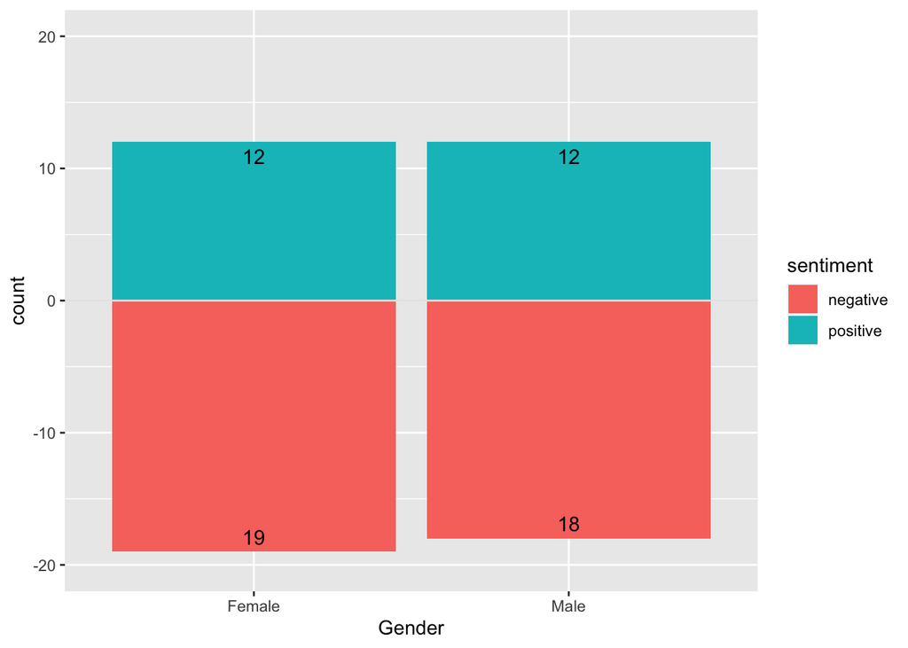

```r
#Generate the Dataset for the Plot
plotDf <- wordDf %>%
  inner_join(get_sentiments("bing")) %>%
  group_by(Gender, sentiment) %>%
  count(sentiment) %>%
  rename(count = n)
#Generate the Barplot for the Positive/Negative Sentiment
#For Each Age Group
ggplot(plotDf, aes(Gender), ylim(-20:20)) +
geom_bar(data = subset(plotDf, sentiment == "positive"),
   aes(y = count, fill = sentiment), stat = "identity", position = "dodge") +
geom_bar(data = subset(plotDf, sentiment == "negative"),
   aes(y = -count, fill = sentiment), stat = "identity", position = "dodge") +
geom_hline(yintercept = 0,colour = "grey90") +
  #Now Add the Tect to it
geom_text(data = subset(plotDf, sentiment == "positive"),
      aes(Gender, count, group=sentiment, label=count),
        position = position_dodge(width=0.9), vjust = 1.5, size=4) +
geom_text(data = subset(plotDf, sentiment == "negative"),
      aes(Gender, -count, group=sentiment, label=count),
        position = position_dodge(width=0.9), vjust = -.5, size=4) +
    coord_cartesian(ylim = c(-20, 20))
```

Let’s use `affin` again and calculate the average sentiment for each sex.

```r
#Calculate Average sentiment for each inmate
avgSentSex <- wordDf %>%
  inner_join(get_sentiments("afinn")) %>%
  group_by(Gender) %>%
  summarise( totalWords = sum(count), sentSum = sum(value)) %>%
  mutate(Avg_Sentiment = sentSum / totalWords)
#Print the dataset
head(avgSentSex, n=20)
```

```
## # A tibble: 2 x 4
##   Gender totalWords sentSum Avg_Sentiment
##   <chr>       <int>   <dbl>         <dbl>
## 1 Female        832     -12      -0.0144
## 2 Male          959      -9      -0.00938
```

Let’s check the count of distinct words used by each income group and remove the stop words before do the count.

```r
#Word Count by each Inmate
wordDf <- sfoDf %>%
  select(Q7_text_All, Income) %>%
   rename(Comments = Q7_text_All) %>%
  unnest_tokens(word, Comments) %>%
  anti_join(stop_words) %>%
  na.omit() %>%
  group_by(Income, word) %>%
  summarise(count = n())
#Check the data set
head(wordDf, n = 20)
```

```
## # A tibble: 20 x 3
## # Groups:   Income [1]
##    Income            word          count
##    <chr>             <chr>         <int>
##  1 $100,001-$150,000 ac                1
##  2 $100,001-$150,000 access           12
##  3 $100,001-$150,000 air               3
##  4 $100,001-$150,000 airline          35
##  5 $100,001-$150,000 airlines         11
##  6 $100,001-$150,000 airport         116
##  7 $100,001-$150,000 airtrain          8
##  8 $100,001-$150,000 amenities        21
##  9 $100,001-$150,000 announcements     2
## 10 $100,001-$150,000 artwork          12
## 11 $100,001-$150,000 atm’s             7
## 12 $100,001-$150,000 bad               3
## 13 $100,001-$150,000 baggage           3
## 14 $100,001-$150,000 bart              6
## 15 $100,001-$150,000 bilingual         2
## 16 $100,001-$150,000 booth             2
## 17 $100,001-$150,000 bring             1
## 18 $100,001-$150,000 business          7
## 19 $100,001-$150,000 car              13
## 20 $100,001-$150,000 carts             5
```

Let’s count positive and negative words for each income group and calculate the sentiment.

```r
#Count positive and negative words
wordSent_bing <- wordDf %>%
  inner_join(get_sentiments("bing")) %>%
  group_by(Income, sentiment) %>%
  count(sentiment)  %>%
  spread(sentiment, n, fill = 0) %>%
  mutate(sentiment = positive - negative)
#Print the dataset
head(wordSent_bing, n= 10)
```

```
## # A tibble: 4 x 4
## # Groups:   Income [4]
##   Income            negative positive sentiment
##   <chr>                <dbl>    <dbl>     <dbl>
## 1 $100,001-$150,000       18       11        -7
## 2 $50,000-$100,00         19       11        -8
## 3 Over $150,000           18       12        -6
## 4 Under $50,000           18       11        -7
```

The sentiment is dominantly negative for all income group.

We can plot this data as well.

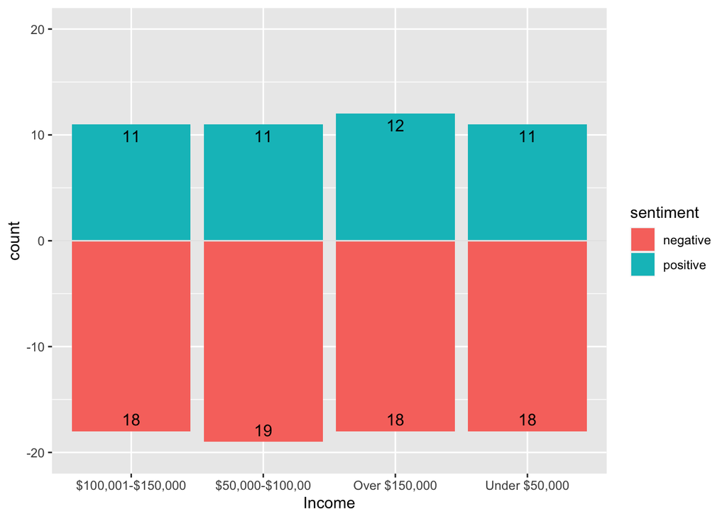

```r
#Generate the Dataset for the Plot
plotDf <- wordDf %>%
  inner_join(get_sentiments("bing")) %>%
  group_by(Income, sentiment) %>%
  count(sentiment) %>%
  rename(count = n)
#Generate the Barplot for the Positive/Negative Sentiment
#For Each Age Group
ggplot(plotDf, aes(Income), ylim(-20:20)) +
geom_bar(data = subset(plotDf, sentiment == "positive"),
   aes(y = count, fill = sentiment), stat = "identity", position = "dodge") +
geom_bar(data = subset(plotDf, sentiment == "negative"),
   aes(y = -count, fill = sentiment), stat = "identity", position = "dodge") +
geom_hline(yintercept = 0,colour = "grey90") +
  #Now Add the Tect to it
geom_text(data = subset(plotDf, sentiment == "positive"),
      aes(Income, count, group=sentiment, label=count),
        position = position_dodge(width=0.9), vjust = 1.5, size=4) +
geom_text(data = subset(plotDf, sentiment == "negative"),
      aes(Income, -count, group=sentiment, label=count),
        position = position_dodge(width=0.9), vjust = -.5, size=4) +
    coord_cartesian(ylim = c(-20, 20))
```

We can use `affin` again and calculate the average sentiment for all income groups.

```r
#Calculate Average sentiment for each inmate
avgSentIncome <- wordDf %>%
  inner_join(get_sentiments("afinn")) %>%
  group_by(Income) %>%
  summarise( totalWords = sum(count), sentSum = sum(value)) %>%
  mutate(sentiment = sentSum / totalWords)
#Print the dataset
head(avgSentIncome, n=20)
```

```
## # A tibble: 4 x 4
##   Income            totalWords sentSum sentiment
##   <chr>                  <int>   <dbl>     <dbl>
## 1 $100,001-$150,000        305     -10   -0.0328
## 2 $50,000-$100,00          476     -12   -0.0252
## 3 Over $150,000            394      -8   -0.0203
## 4 Under $50,000            321     -11   -0.0343
```

#### Part B

### Topic Models

Let’s try topic models to find out the themes.

```r
feedbackText = textProcessor(documents = sfoDf$Q7_text_All,
                           metadata = sfoDf)
```

```
## Building corpus...
## Converting to Lower Case...
## Removing punctuation...
## Removing stopwords...
## Removing numbers...
## Stemming...
## Creating Output...
```

We might need to do some encoding conversion, remove non-graphical characters within the data, and remove that offending character. Let’s check for encoding in the dataset.

```r
rvest::guess_encoding(sfoDf$Q7_text_All)
```

```
##       encoding language confidence
## 1        UTF-8                1.00
## 2 windows-1252       en       0.48
## 3 windows-1250       ro       0.20
## 4     UTF-16BE                0.10
## 5     UTF-16LE                0.10
## 6    Shift_JIS       ja       0.10
## 7      GB18030       zh       0.10
## 8         Big5       zh       0.10
## 9 windows-1254       tr       0.08
```

We see the word “airport” in a lot of the entries. We don’t want this messing with my topics on down the line, so let’s see how much it is around.

```r
#Convert the comments to all uppercase
sfoDf$Q7_text_All <- toupper(sfoDf$Q7_text_All)
#Find the frequency of airport
nrow(sfoDf[grepl("AIRPORT", sfoDf$Q7_text_All), ])
```

```
## [1] 480
```

We see ‘airport’ is used almost 500 times. We can add the word ‘airport’ in the stopwords list. In addition to custom stopwords, we’ll also like to include the SMART words again (it is the default) and the english stopwords.

```r
feedbackTextProcess = textProcessor(documents = sfoDf$Q7_text_All,
                           metadata = sfoDf,
                           onlycharacter = TRUE,
                           customstopwords = c("airport",
                                               tm::stopwords("SMART"),
                                               tm::stopwords("en")))
```

```
## Building corpus...
## Converting to Lower Case...
## Removing punctuation...
## Removing stopwords...
## Remove Custom Stopwords...
## Removing numbers...
## Stemming...
## Creating Output...
```

```r
feedbackTextPrep = prepDocuments(documents = feedbackTextProcess$documents,
                               vocab = feedbackTextProcess$vocab,
                               meta = feedbackTextProcess$meta)
```

```
## Removing 6 of 188 terms (6 of 12168 tokens) due to frequency
## Your corpus now has 1557 documents, 182 terms and 12162 tokens.
```

The `stm` package has some pretty nice facilities for determining a number of topics. We can try topics from 2 to 5 and see what we get.

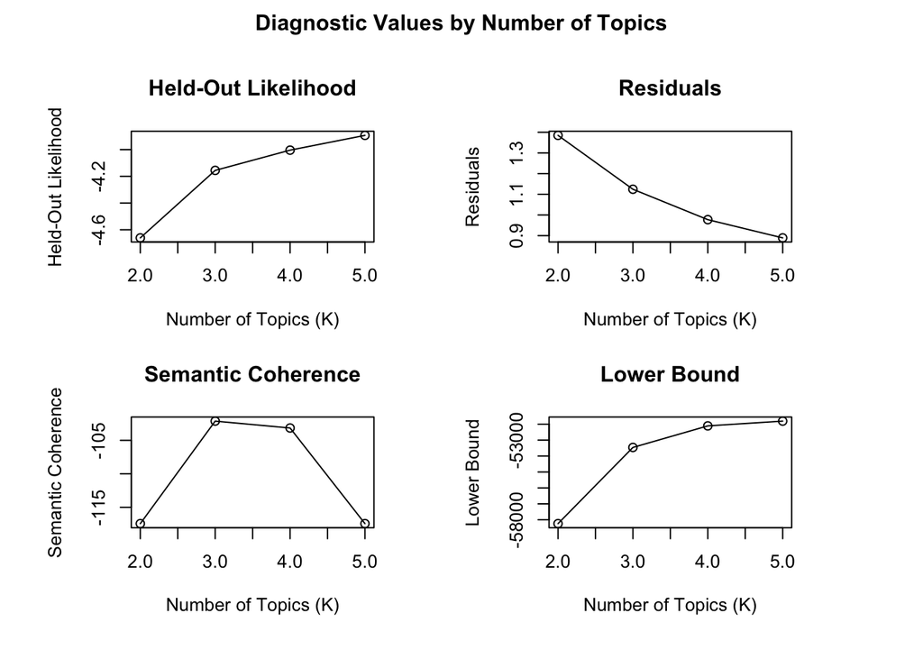

```r
kTest = searchK(documents = feedbackTextPrep$documents,
             vocab = feedbackTextProcess$vocab,
             K = c(2, 3, 4, 5), verbose = FALSE)

plot(kTest)
```

Looking at the residual and Semantic Coherence we think 4 topics is the best to go for. With our 4 topics, we can start our actual model.

```r
topics4 = stm(documents = feedbackTextPrep$documents,
             vocab = feedbackTextPrep$vocab,
             K = 4, verbose = FALSE)
```

If we plot the stm result, we get the proportional prevalence of the topics, with some keywords for each topic.

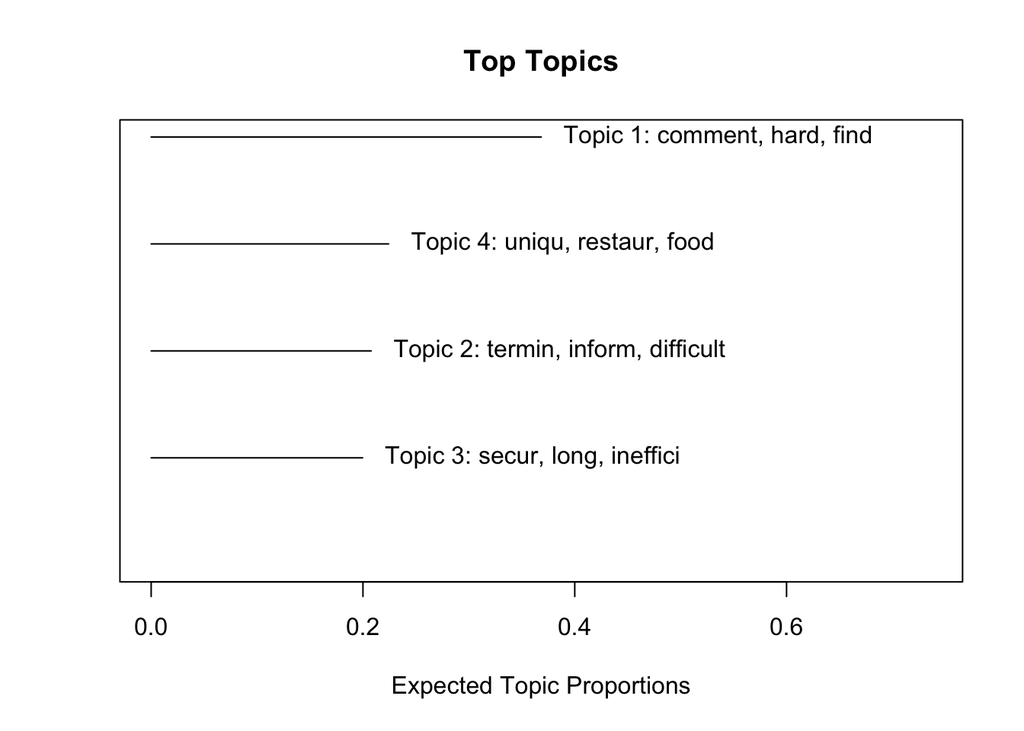

```r
plot(topics4)
```

Additional functions can help to understand the words that fall into each topic, which assist in identifying and labeling the topics.

```r
labelTopics(topics4)
```

```
## Topic 1 Top Words:
##       Highest Prob: comment, hard, find, signag, confus, posit, airlin
##       FREX: comment, find, signag, posit, general, sfo, area
##       Lift: area, correct, neg, pos, signag, water, comment
##       Score: comment, find, electr, sfo, signag, area, posit
## Topic 2 Top Words:
##       Highest Prob: termin, inform, difficult, small, chang, amen, personnel
##       FREX: inform, chang, amen, display, lack, rapid, screen
##       Lift: amen, atm, autom, booth, chang, check, clock
##       Score: inform, outlet, rapid, screen, small, display, lack
## Topic 3 Top Words:
##       Highest Prob: secur, long, ineffici, custom, line, ineffect, procedur
##       FREX: secur, ineffici, custom, line, ineffect, procedur, seat
##       Lift: allow, crowd, custom, cut, effici, front, healthier
##       Score: custom, ineffici, line, ineffect, procedur, secur, healthier
## Topic 4 Top Words:
##       Highest Prob: uniqu, restaur, food, expens, shop, free, servic
##       FREX: uniqu, restaur, expens, shop, access, wifi, cover
##       Lift: luggag, uniqu, access, air, bad, chain, club
##       Score: restaur, uniqu, expens, cover, entir, overload, didn
```

From the plot of the topics and from the example words we can conclude that -

- Topic 1 is likely expressing about the directions and signs in the SFO airport
- Topic 2 is likely expressing about the small display and lack of information displayed.
- Topic 3 likely expressing about the customs and security inefficiency and long waiting time.
- Topic 4 likely expressing about the restaurants availability and food choices.

We can look at statements that have a high probability of being associated with each topic here. This presents documents that are representative of each topic.

```r
findThoughts(topics4, texts = feedbackTextPrep$meta$Q7_text_All , n = 1)
```

```
##
##  Topic 1:
##        GENERAL CLEANLINESS POS COMMENT  BART GROUND TRANSPORTATION POS COMMENT  SIGNAGE INSIDE AIRPORT CONFUSING SMALL HARD TO FIND GATE OR AIRLINE
##  Topic 2:
##        INFORMATION SCREENS TOO SMALL NOT ENOUGH LACK INFORMATION DISPLAYS CHANGE TOO RAPIDLY  INFORMATION BOOTH NOT STAFFED PERSONNEL UNHELPFUL NOT KNOWLEDGEABLE  MORE HUMANS FEWER ELECTRONIC AUTOMATED SIGNS
##  Topic 3:
##        SECURITY CUSTOMS LINES PROCEDURES LONG INEFFICIENT INEFFECTIVE  SECURITY CUSTOMS PERSONNEL INEFFICIENT RUDE NOT WELL TRAINED  DON’T APPRECIATE PEOPLE CUTTING IN LINE BEING ALLOWED IN FRONT OF ME
##  Topic 4:
##        NEED FAST FOOD CHAIN RESTAURANTS  WIFI NOT FREE LONG ENOUGH DIFFICULT TO ACCESS DOESN’T COVER ENTIRE AIRPORT OVERLOADED DIDN’T KNOW WAS AVAILABLE
```

We can see the statements are along the expectations we mentioned earlier by each topic.